# Linear Regression Intro

Home | Linear Regression

## Idea

We have data points $(x_i, y_i)$, where each $x_i$ corresponds to a $y_i$.

The goal is to fit a line that represents the underlying trend in the data.

## Model 1

We can form a model the following way:

$$y_i = \beta_0 + \beta_1x_i + \epsilon_i$$

Where:

- $i \in \{1,...,n\}$
- $y_i$ is the ith output value
- $x_i$ is the ith input value
- $\beta_0$ is the y-intercept
- $\beta_1$ is the rate of change (or slope)
- $\epsilon_i$ is the ith error
  - $\epsilon_i ~ \mathcal{N}(0, \sigma^2)$ (mean 0 and variance $\sigma^2$)
  - it is the difference between the predicted value $\hat{y}_i = \beta_0 + \beta_1x_i$ and the actual value $y_i$

## Model 2

We can otherwise write our model the following way:

$$\mathbf{E}(Y|X=x) = \beta_0 + \beta_1x$$

$$var(Y|X=x) = \sigma^2$$

## R Sample

Here is a sample of linear regression with R.

Y is set to be a vector of Y values and X is set to be a vector of X values

c(…) creates a vector of the given values

" <- " is the assignment operator, similar to " = " in other programming languages such as python.

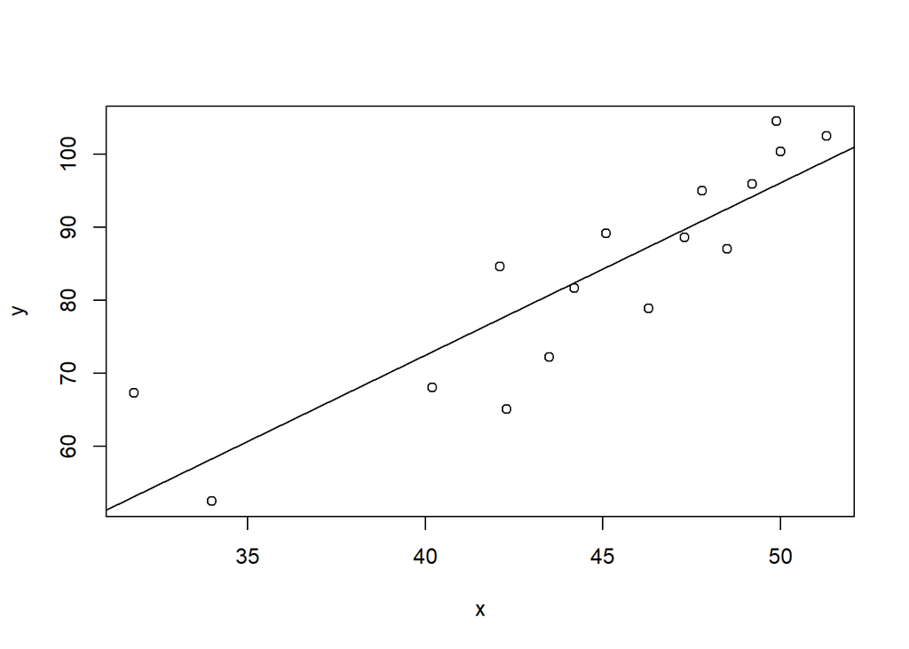

```r
Y <- c(102.5, 104.5, 100.4, 95.9, 87.0, 95.0, 88.6, 89.2,
78.9, 84.6, 81.7, 72.2, 65.1, 68.1, 67.3, 52.5)
X <- c(51.3, 49.9, 50.0,49.2, 48.5, 47.8, 47.3, 45.1,
46.3, 42.1, 44.2, 43.5, 42.3, 40.2, 31.8, 34.0)
plot(X,Y,xlab="x",ylab="y")
myFit <- lm(Y~X) # M is the response variable and T the predictor
abline(myFit) # Add regression line to the plot
```